תמצית למקבלי החלטות · הרכבת הקלה נופית · אוקטובר 2026

# האם להמשיך את הרכבת הקלה נופית דרך חיפה עד טירת כרמל?

מה אומרות הראיות על הביקוש לנסיעות, בשפה פשוטה. הוכן למקבלי החלטות מתוך הדוח המסכם של 5 באוקטובר 2026.

תרחיש הייחוסשנת 2050, צמיחה רגילה, רכבת עם עדיפות בצמתים

התקופהשיא הבוקר, 06:00–09:00, אלא אם צוין אחרת

ניווטמקשי החצים, רווח, או הכפתורים למטה

התשובה בקצרה

## להארכה יש שוק אמיתי בסדר גודל של רכבת קלה. היא זקוקה לעדיפות בצמתים יותר משהיא זקוקה לקו רציף, והמספרים בשלים לקביעת גודל הקו, לא עדיין לרכישת קרונות.

7,400נוסעים בקו כולו בכל שיא בוקר ב-2050

4 מתוך 5מהם משתמשים בהארכה דרך חיפה

−23 %מהנוסעים אובדים אם הרכבת ממתינה בצמתים כמו מכונית

### מה הראיות אומרות

- הנוסעים נמצאים בחיפה ובטירת כרמל, בשלושה שווקים בגודל דומה.
- רובם עוברים מהמטרונית ומהאוטובוסים. מעטים עוזבים את הרכב הפרטי.
- קו רציף עד נצרת חוסך החלפת כלי רכב; הוא אינו מוסיף נוסעים להארכה.

### מה אנחנו מבקשים להחליט

- לתכנן על תרחיש הייחוס 2050, עם 5,500 עד 10,500 נוסעי בוקר כטווח.
- לשמור בתכנון על עדיפות לרכבת בצמתים.
- להכריע בעתיד המטרונית על הציר המשותף לפני כל עבודת קיבולת.

מקור: התמצית למקבלי ההחלטות בדוח המסכם.

השאלה

## הקו הראשי עד נצרת נמצא בבנייה. השאלה היא אם להמשיך אותו 18.7 ק"מ דרך חיפה עד טירת כרמל, ואם להפעיל את שניהם כקו אחד.

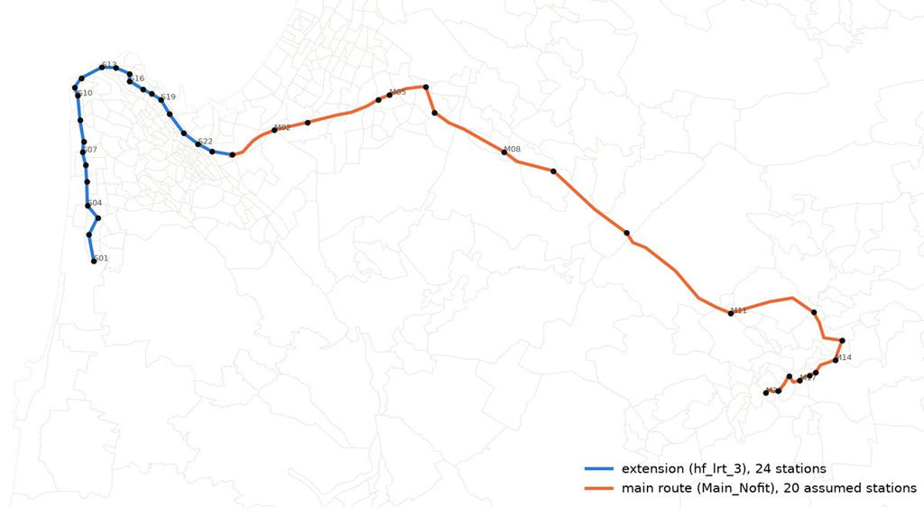

ההארכה (כחול, תחנות S01–S24) והקו הראשי (כתום, M01–M20). שניהם נפגשים במפרץ. כיתובי המפה באנגלית.

ההארכה24 תחנות, 18.7 ק"מ לאורך חוף הים והעיר התחתית

מטירת כרמל למפרץ41 דקות עם עדיפות בצמתים; 66 דקות בלעדיה

השירות שהונחרכבת כל 5 דקות, שנוסעת ברצף עד נצרת ללא החלפה

שלוש הכרעות על השולחןלבנות את ההארכה או לא · קו אחד או שניים · עדיפות בצמתים או לא

מקור: פרק 1 וטבלה 4.10 בדוח המסכם; המפה מתוך Output/figures/lrt_alternatives_lines.png.

איך ענינו

## לקחנו את הנוסעים של היום, הגדלנו אותם ל-2050, והצענו להם את הרכבת הקלה כאפשרות חדשה.

1. 1

   **הנסיעות של היום.** מי נוסע לאן בשיא הבוקר, ברכב, באוטובוס, במטרונית וברכבת, מסקר הנסיעות של משקי הבית ומכרטוס הרב-קו, בבדיקה מול ספירות תנועה.
2. 2

   **צמיחה ל-2040 ול-2050.** אותה תבנית נסיעות, מוגדלת לפי תחזיות האוכלוסייה והתעסוקה הרשמיות. הנסיעות במסדרון גדלות ב-30 עד 60 אחוז. ההרגלים נשארים כמו ב-2022.
3. 3

   **השירות של היום, ועליו הרכבת הקלה.** לוח הזמנים של מאי 2026 והמהירויות שנמדדו לכל נסיעת אוטובוס, מטרונית ורכב. הרכבת הקלה מתווספת כאפשרות חדשה; שום דבר אחר לא מבוטל ולא משתנה.
4. 4

   **מי עובר.** הנוסעים בוחרים בנסיעה שמרגישה הקצרה ביותר: הנסיעה עצמה, ההליכה, ההמתנה והחלפות כלי הרכב כולן נספרות. אנחנו סופרים כמה בוחרים ברכבת הקלה, ומאיזה אמצעי.

התוצאה היא סינון ביקוש למסדרון, בשרשרת מתועדת וניתנת לשחזור של 45 שלבים. זה אינו מודל תחבורה אזורי מלא ואינו הערכה כלכלית.

מקור: פרק 2 בדוח המסכם.

כמה

## כ-7,400 איש ייסעו בקו בשיא הבוקר ב-2050, וארבעה מכל חמישה מהם משתמשים בהארכה.

[figure not shown]

- הקו כולו (טירת כרמל – נצרת)
- מתוכם משתמשים בהארכה

נוסעי בוקר ברכבת הקלה, 06:00–09:00, עם עדיפות בצמתים. "רגיל" הוא תרחיש הצמיחה הרגיל; "גבוה" הוא תרחיש הצמיחה הגבוה.

שעת השיא, 2050כ-4,400 נוסעים בקו

שיא אחר הצהרייםכ-85 אחוז מהבוקר

צמיחה מ-2040 ל-2050כ-18 אחוז, בקצב המסדרון

תרחיש הצמיחה הגבוהמוסיף 15 עד 25 אחוז באותה שנה

מקור: טבלה 4.3 בדוח המסכם.

איפה

## הנוסעים נמצאים בחיפה ובטירת כרמל: שלושה שווקים בגודל דומה מהווים שלושה רבעים מהביקוש.

[figure not shown]

נוסעי בוקר ברכבת הקלה לפי האזורים בשני קצות הנסיעה, 2050, שני הכיוונים. בסוגריים החלק מכלל 7,400 הנוסעים.

הזרם הבודד הגדול ביותרטירת כרמל ↔ בת גלים, 820 נוסעים בבוקר

חציית המפרץ38 אחוז מהנוסעים נוסעים בין שני חלקי הקו

הקריותמחוץ לקו; התושבים מגיעים אליו במטרונית או באוטובוס מזין

הקו הראשי מעבר לקריית אתאכמה מאות נוסעים לכיוון

מקור: טבלאות 4.5 ו-4.7 בדוח המסכם.

מאיפה

## רוב הנוסעים הם נוסעי המטרונית והאוטובוסים של היום בכלי מהיר יותר. הרכב הפרטי מוותר על פחות מנסיעה אחת ממאה.

- מטרונית: 33 % מנוסעיה במסדרון
- אוטובוסים: 31 % מנוסעיהם במסדרון
- רכב פרטי: 0.9 % מנסיעות הרכב במסדרון

מאיפה מגיעים 7,400 נוסעי הבוקר של הרכבת הקלה ב-2050.

חלק התחבורה הציבורית בנסיעות במסדרון19.3 % לפני הרכבת הקלה, 20.6 % אחריה

מה זה אומרהרכבת הקלה מארגנת מחדש את התחבורה הציבורית יותר משהיא יוצרת נסיעות חדשות

מה לא להבטיחהקלה גדולה בכבישים. המעבר מהרכב הוא כמה מאות עד כאלף נסיעות, והוא המספר הכי פחות ודאי כאן

מקור: טבלה 4.3 ופרק 4.4 בדוח המסכם.

קו אחד או שניים

## קו רציף עד נצרת אינו מוסיף נוסעים להארכה. מה שהוא קונה הוא החלפת כלי רכב שנחסכת ל-38 האחוזים שחוצים את המפרץ.

[figure not shown]

- ההארכה מסתיימת במפרץ
- קו אחד רציף עד נצרת

נוסעי בוקר ב-2050, עם עדיפות בצמתים. סיום במפרץ נבדק; הקו הראשי לבדו לא.

נוסעי ההארכה6,003 כקו אחד, 5,939 אם היא מסתיימת במפרץ: הבדל של אחוז אחד

מי מרוויח מקו אחד2,849 נוסעים בבוקר שאחרת היו מחליפים רכבת במפרץ. המטרונית מסיעה אותם היום ברצף

מקור: טבלה 4.1 ופרק 4.1 בדוח המסכם.

עדיפות בצמתים

## עדיפות בצמתים שווה רבע מהנוסעים, יותר מעשר שנות צמיחה.

נוסעי בוקר ברכבת הקלה בקו כולו. "בלי עדיפות" פירושו שההארכה נוסעת ברמת הרחוב וממתינה בצמתים עם התנועה.

מטירת כרמל למפרץ41 דקות עם עדיפות, 66 בלעדיה

עשר שנות צמיחהמוסיפות 18 אחוז נוסעים

אובדן העדיפותמוריד 23 אחוז, רובם על ההארכה עצמה

בכל תרחיש ותקופהההפסד הוא 20 עד 23 אחוז

מקור: טבלאות 4.8 ו-4.10 בדוח המסכם.

כמה עמוס

## בשעה העמוסה ביותר עוברים בצומת המפרץ כ-1,000 עד 1,100 נוסעים לכיוון: ביקוש בסדר גודל של רכבת קלה, לא של מטרו.

[figure not shown]

הקטע העמוס ביותר, שעת שיא הבוקר, כיוון אחד, עם עדיפות בצמתים. אלה תנועות פוטנציאליות ללא מגבלת קיבולת.

הנקודה העמוסה ביותרהכניסה למפרץ לכיוון טירת כרמל בבוקר

על ההארכה עצמהכ-1,030 לשעה ב-2050, על חוף הכרמל

אחר הצהרייםנמוך יותר ומאוזן יותר בין שני הכיוונים

מקור: טבלה 4.2a ופרק 4.5 בדוח המסכם.

כמה בטוח

## טווח תכנון הוגן הוא 5,500 עד 10,500 נוסעי בוקר. המספר המרכזי נמצא בצד הזהיר.

[figure not shown]

הטווח נובע מעד כמה הנוסעים מגיבים לנסיעה מהירה יותר, אי-הוודאות הבודדת הרחבה ביותר שנבדקה.

החלק המוצקהמעבר מהמטרונית ומהאוטובוסים נשען על נסיעות שנצפו ועל לוחות זמנים שנמדדו

החלק הרךהמעבר מהרכב הפרטי. יש לקרוא אותו כסדר גודל

הנחה זהירההכבישים והאוטובוסים שומרים על מהירויות 2026 גם ב-2050. אם האוטובוסים יואטו בפקקים, הרכבת הקלה מרוויחה כ-5 אחוז

מקור: טווח התכנון בתמצית; פרקים 3.4 ו-4.9 בדוח המסכם.

השאלה הפתוחה

## השאלה הפתוחה הגדולה ביותר אינה במודל: האם המטרונית והרכבת הקלה יחלקו את הציר?

### מה המודל מניח

- כל קו מטרונית ואוטובוס ממשיך לנסוע לצד הרכבת הקלה, בדיוק כמו היום.
- כשליש מנוסעי המטרונית במסדרון עוברים; 7,800 נשארים כי נסיעתם עדיין מהירה יותר במטרונית.
- זהו המקרה הזהיר עבור הרכבת הקלה.

### מה תעשה החלטה על הרשת

- צמצום המטרונית בקטע החופף, ועד 11,300 נסיעות הבוקר שלה במסדרון עשויות לעבור לרכבת הקלה.
- ארגון מחדש של המטרונית כמזינה לתחנות הרכבת הקלה, והרכבת הקלה מרוויחה נוסעים גם כך.
- כל אחת מההכרעות מזיזה את המספרים יותר מכל אי-ודאות בדוח הזה. יש להכריע בה לפני שמשתמשים בהם לקיבולת.

מקור: פרק 4.4 בדוח המסכם.

למה המספרים מתאימים

## להשתמש במספרים האלה כדי לאמוד את השוק ולדרג את החלופות. לא להשתמש בהם עדיין כדי לרכוש קרונות או לקבוע תדירויות.

### מתאים ל

- אומדן שוק ההארכה ומיקומו: אילו אזורים, אילו תחנות.
- דירוג החלופות: קו אחד או שניים, עדיפות או לא.
- סדר הגודל של המעבר מהמטרונית, מהאוטובוסים ומהרכב.
- סדר הגודל של עומס השיא, לשעת התכן.

### עדיין לא מתאים ל

- גודל הצי, תדירויות או קיבולת: לעומסים אין מגבלת קיבולת והם לא נבדקו קטע-קטע.
- הערכה כלכלית.
- כל טענה על עומסי תנועה בכבישים ב-2040 או ב-2050.
- מספרים לתחנה בודדת או לשכונה בודדת.

מקור: פרק 3.5 בדוח המסכם.

הבקשה

## חמש הכרעות שאנחנו מבקשים לקבל.

1. 1

   **לתכנן על תרחיש הייחוס 2050.** כ-7,400 נוסעי בוקר בקו, 6,000 מהם על ההארכה, עם 5,500 עד 10,500 כטווח התכנון.
2. 2

   **לשמור בתכנון על עדיפות בצמתים.** בלעדיה רבע מהנוסעים הולכים לאיבוד, והנסיעה מטירת כרמל למפרץ נמשכת 66 דקות במקום 41.
3. 3

   **להתייחס לקו הרציף כשאלה של מעברים, לא של מספר נוסעים.** קו אחד חוסך ל-2,849 נוסעים בבוקר החלפת רכבת במפרץ; הוא אינו מוסיף נוסעים להארכה.
4. 4

   **להכריע בעתיד המטרונית על הציר המשותף** לפני כל עבודת קיבולת או צי, כי ההכרעה הזאת מזיזה את המספרים יותר מכל אי-ודאות כאן.
5. 5

   **להזמין ארבע עבודות לפני הערכה כלכלית:** פיצול הנסיעות לפי מטרה, תחזית אחר-צהריים מסודרת, תוכנית ההפעלה של הקו הראשי, וסקר על נכונות בעלי הרכב לעבור.

מקור: התמצית למקבלי ההחלטות ופרק 5 בדוח המסכם.

בנשימה אחת

## שוק בסדר גודל של רכבת קלה בחיפה ובטירת כרמל, שרובו מגיע מהתחבורה הציבורית של היום, ושחי או מת על עדיפות בצמתים.

7,400נוסעי בוקר בקו ב-2050; ארבעה מכל חמישה על ההארכה

3שווקים בגודל דומה: טירת כרמל ↔ חיפה, בתוך חיפה, הקריות בהזנה

−23 %בלי עדיפות בצמתים, יותר ממה שעשר שנות צמיחה מוסיפות

+1 %נוסעי הארכה מקו רציף עד נצרת; הרווח הוא מעבר שנחסך

הצעד הבא: להכריע בשאלת המטרונית, לשמור על העדיפות, ולהזמין את ארבע העבודות לפני כל הערכה כלכלית או החלטה על צי.

נספח

## מאיפה המספרים.

### הנתונים מאחורי המחקר

- סקר הנסיעות של משקי הבית 2017/18: 16,401 אנשים, 5,108 משקי בית.
- נסיעות אוטובוס מכרטוס הרב-קו, מאי 2022; עליות עד 2025.
- תחזיות אוכלוסייה ותעסוקה ל-2040 ול-2050, שני תרחישים (רגיל, גבוה).
- לוח הזמנים הארצי של 22 במאי 2026; מהירויות אוטובוס ורכב שנמדדו, מאי 2026.
- התוואי והתחנות המתוכננים של ההארכה (22 בספטמבר 2026) ושל הקו הראשי (5 באוקטובר 2026).
- זמני הנסיעה של הרכבת הקלה הועברו מהקו האדום בתל אביב.

### מונחים

- **רגיל / גבוה**: התרחישים הדמוגרפיים הרגיל והגבוה (BU / HS בדוח).
- **עם עדיפות**: הרכבת מקבלת ירוק בצמתים ("Prioritized" בדוח). בלי עדיפות: נסיעה ברמת הרחוב, המתנה עם התנועה ("Unprioritized").
- **שיא הבוקר**: נסיעות שיוצאות בין 06:00 ל-09:00. השעה העמוסה היא כ-59 אחוז מהן.
- **נוסעים**: עליות לרכבת הקלה, כולל נסיעות שמתחילות או מסתיימות באוטובוס מזין או במטרונית.
- **המסדרון**: 25 אזורים ו-174 אזורי תנועה מטירת כרמל עד נצרת.

כל מספר ניתן לאיתור בדוח reports/Nofit_LRT_Extension_Comprehensive_Report.docx ובקבצים תחת Output/ שהוא מציין. המצגת נבנית על ידי tools/build_decision_deck.py.

נספחים

## ארבעה עמודי רקע למי שרוצה לראות איך נבנו המספרים.

1. א

   **איך נמדדה מהירות הרכבת הקלה.** על הקו האדום בתל אביב, ומשם למרווח התחנות בחיפה.
2. ב

   **כמה עולות הליכה, המתנה והחלפת כלי רכב.** המשקולות שהמודל משתמש בהן, מה המחקר מצא, וכמה הן מזיזות את התוצאה.
3. ג

   **איך הפרש עלות הופך לנוסעים.** מקדם הרגישות λ, עם דוגמאות מחושבות.
4. ד

   **מה יש בעלות המוכללת.** הנוסחה, מאיפה היא באה, ונסיעה מחושבת.

הנספחים המלאים, עם המקורות, נמצאים בדוח המסכם (נספחים א–ד).

נספח א · מהירות הרכבת הקלה

## מהירות הרכבת נמדדה על הקו האדום בתל אביב: 46 קמ"ש בין תחנות ועוד כ-50 שניות בכל עצירה.

[figure not shown]

- קו מופרד (משמש ל"עם עדיפות")
- קו ברמת הרחוב (משמש ל"בלי עדיפות")

זמן מתחנה לתחנה כפונקציה של מרווח התחנות, מ-26,653 נסיעות שנמדדו בקו האדום (2024 עד 2026).

למה נמדד ולא הונחמהירות תכן מחמיצה בלימה, שהייה, האצה והמתנה בצמתים; הקו האדום נוסע גם מופרד וגם ברחוב

התיקון שהיה חשובדוח הכיול הניח 500 מטר בין תחנות; המרווח האמיתי בקו האדום הוא 970 מטר בתת-הקרקע, ולכן הקריאה הראשונה הפכה את הקו לאיטי פי שניים

על ההארכה40.7 דקות מקצה לקצה עם עדיפות, 65.8 בלעדיה. הקו הראשי לנצרת מוגדר ב-80 קמ"ש, לא נמדד

מקור: נספח א בדוח המסכם.

נספח ב · הזמן מחוץ לרכב

[figure not shown]

נוסעי בוקר ברכבת הקלה במבחן 2022 של ההארכה לבדה (25 אזורים), בשש קבוצות משקולות. תרחיש הייחוס יושב בין השורה השנייה לחמישית.

מה המודל משתמש בו היוםהליכה והמתנה נספרות כפליים; 8 דקות להחלפה מאוטובוס, 4 ממטרונית; חצי דקה בתוך כל תחנה; הליכה ב-4 קמ"ש; בונוס של 5 דקות לרכבת על פני אוטובוס (2.5 על פני המטרונית)

מאיפה הערכיםהנחיות הערכה של אחת-עשרה מדינות וישראל, ספרות ערך הזמן, ועשרה מודלים אזוריים מכוילים. המסמכים הישראליים טרם נקראו במלואם

עדיין פתוחתכנון התחנות והמעברים, שמכריע את שני הרכיבים החשובים ביותר

מקור: נספח ב בדוח המסכם.

נספח ג · מקדם הרגישות λ

## λ הופך הפרש עלות לנוסעים: יתרון של 10 דקות נותן לרכבת הקלה כ-65 % מנוסעי התח"צ בזוג אזורים.

[figure not shown]

- λ_T = 0.06 (בשימוש)
- λ_T = 0.03 ו-0.10 (הטווח הנישא)

עלות שווה מחלקת את הנוסעים שווה בשווה. כל דקה מורגשת של יתרון מזיזה את הסיכויים בכ-6 % בין שני מסלולי תח"צ ובכ-3 % בין הרכב לתח"צ.

שני מקדמי רגישות0.06 בין שני מסלולי תח"צ; 0.03 בין הרכב לתח"צ, שמגיב בערך בחצי מהעוצמה

נאמד מהסקר0.035 כשזמינות הרכב מוחזקת קבועה, מה שתומך ב-0.03 שבשימוש. לבעלי רכב לא ניתן היה למדוד

מה הוא עושה לתוצאהטווח ה-λ לבדו משתרע על −26 % עד +42 % מהנוסעים: המקור לטווח התכנון 5,500 עד 10,500

מקור: נספח ג בדוח המסכם.

נספח ד · העלות המוכללת

## העלות המוכללת היא כמה הנסיעה מרגישה ארוכה. בדוגמה המחושבת הרכבת הקלה הולכת יותר ועדיין זולה בעשר דקות מורגשות.

- נסיעה
- הליכה × 2
- המתנה × 2
- בונוס הרכבת (−5)

מקריית חיים לבת גלים. אוטובוס: 28 דקות נסיעה, 10 הליכה, 5 המתנה. רכבת קלה: 20 נסיעה, 14 הליכה, 2.5 המתנה (רכבת כל 5 דקות).

הנוסחהנסיעה + 2 × הליכה + 2 × המתנה + 8 לכל החלפה (4 ממטרונית לרכבת הקלה) + 0.5 לכל קצה תחנה − בונוס הרכבת

בלי כסףהתעריף אחיד ומשולב ולכן מתקזז; אין נתוני חניה לאזור

איך נבנתהקודם משקולות מקובלות, ואז כל מציין מקום הוחלף בנתונים שנמדדו: לוח הזמנים, מהירויות אוטובוס שנמדדו, פונקציית הרכבת המכוילת, ועלויות לכל אזור תנועה על רשת הקווים האמיתית

מקור: נספח ד בדוח המסכם.